# Exam_1

Frederick Abi Chahine

10/16/2021

## Task 1

### Task 1 - Exercise - 1

```r
library(ggplot2)
library(tidyverse)
library(dplyr)
library(ISLR2)
library(reshape2)
library(tidymodels)
library(MASS)
library(boot)
library(pROC)
```

This chunk is simply readying all necessary libraries.

```r
data_set = read.csv("Frederick.csv")
#View(data_set)
names(data_set)
```

```
##  [1] "X"     "resp2" "resp1" "Var1"  "Var2"  "Var3"  "Var4"  "Var5"  "Var6"
## [10] "Var7"  "Var8"  "Var9"  "Var10" "Var11"
```

```r
summary(data_set)
```

```
##        X             resp2            resp1               Var1
##  Min.   :    1   Min.   :0.0000   Min.   :0.000243   Min.   :0.0651
##  1st Qu.: 4125   1st Qu.:0.0000   1st Qu.:0.631000   1st Qu.:0.5270
##  Median : 8250   Median :1.0000   Median :0.801000   Median :0.6480
##  Mean   : 8250   Mean   :0.5524   Mean   :0.761831   Mean   :0.6415
##  3rd Qu.:12374   3rd Qu.:1.0000   3rd Qu.:0.921000   3rd Qu.:0.7680
##  Max.   :16498   Max.   :1.0000   Max.   :1.000000   Max.   :0.9880
##       Var2             Var3              Var4             Var5
##  Min.   : 0.000   Min.   :-32.929   Min.   :0.0227   Min.   :0.0000012
##  1st Qu.: 1.000   1st Qu.: -8.174   1st Qu.:0.0492   1st Qu.:0.0017200
##  Median : 6.000   Median : -6.250   Median :0.0751   Median :0.0167000
##  Mean   : 5.375   Mean   : -6.468   Mean   :0.1365   Mean   :0.0974478
##  3rd Qu.: 9.000   3rd Qu.: -4.518   3rd Qu.:0.1950   3rd Qu.:0.1100000
##  Max.   :11.000   Max.   :  3.108   Max.   :0.9060   Max.   :0.9860000
##       Var6              Var7             Var8             Var9
##  Min.   :0.00000   Min.   :0.0149   Min.   :0.0187   Min.   : 64.33
##  1st Qu.:0.00000   1st Qu.:0.0990   1st Qu.:0.1630   1st Qu.:129.94
##  Median :0.00631   Median :0.1340   Median :0.3250   Median :144.99
##  Mean   :0.28454   Mean   :0.2139   Mean   :0.3583   Mean   :147.78
##  3rd Qu.:0.72500   3rd Qu.:0.2940   3rd Qu.:0.5238   3rd Qu.:162.15
##  Max.   :0.98900   Max.   :0.9790   Max.   :0.9880   Max.   :220.29
##      Var10            Var11
##  Min.   : 25600   Min.   :1.000
##  1st Qu.:179229   1st Qu.:4.000
##  Median :224838   Median :4.000
##  Mean   :250776   Mean   :3.975
##  3rd Qu.:300398   3rd Qu.:4.000
##  Max.   :894386   Max.   :5.000
```

From the summary we can see that all variables are numerical. However, just by looking at the data we can deduce that resp2 needs to be categorical. The chunk below changes its type.

```r
data_set$resp2 <- as.factor(data_set$resp2)
data_set$Var11 <- as.numeric(data_set$Var11)
summary(data_set)
```

```
##        X         resp2        resp1               Var1             Var2
##  Min.   :    1   0:7385   Min.   :0.000243   Min.   :0.0651   Min.   : 0.000
##  1st Qu.: 4125   1:9113   1st Qu.:0.631000   1st Qu.:0.5270   1st Qu.: 1.000
##  Median : 8250            Median :0.801000   Median :0.6480   Median : 6.000
##  Mean   : 8250            Mean   :0.761831   Mean   :0.6415   Mean   : 5.375
##  3rd Qu.:12374            3rd Qu.:0.921000   3rd Qu.:0.7680   3rd Qu.: 9.000
##  Max.   :16498            Max.   :1.000000   Max.   :0.9880   Max.   :11.000
##       Var3              Var4             Var5                Var6
##  Min.   :-32.929   Min.   :0.0227   Min.   :0.0000012   Min.   :0.00000
##  1st Qu.: -8.174   1st Qu.:0.0492   1st Qu.:0.0017200   1st Qu.:0.00000
##  Median : -6.250   Median :0.0751   Median :0.0167000   Median :0.00631
##  Mean   : -6.468   Mean   :0.1365   Mean   :0.0974478   Mean   :0.28454
##  3rd Qu.: -4.518   3rd Qu.:0.1950   3rd Qu.:0.1100000   3rd Qu.:0.72500
##  Max.   :  3.108   Max.   :0.9060   Max.   :0.9860000   Max.   :0.98900
##       Var7             Var8             Var9            Var10
##  Min.   :0.0149   Min.   :0.0187   Min.   : 64.33   Min.   : 25600
##  1st Qu.:0.0990   1st Qu.:0.1630   1st Qu.:129.94   1st Qu.:179229
##  Median :0.1340   Median :0.3250   Median :144.99   Median :224838
##  Mean   :0.2139   Mean   :0.3583   Mean   :147.78   Mean   :250776
##  3rd Qu.:0.2940   3rd Qu.:0.5238   3rd Qu.:162.15   3rd Qu.:300398
##  Max.   :0.9790   Max.   :0.9880   Max.   :220.29   Max.   :894386
##      Var11
##  Min.   :1.000
##  1st Qu.:4.000
##  Median :4.000
##  Mean   :3.975
##  3rd Qu.:4.000
##  Max.   :5.000
```

### Task 1 - Exercise - 2

```r
which(is.na(data_set))
```

```
## integer(0)
```

As we can see from the output, there are no missing (NA) values in our data set.

### Task 1 - Exercise - 3

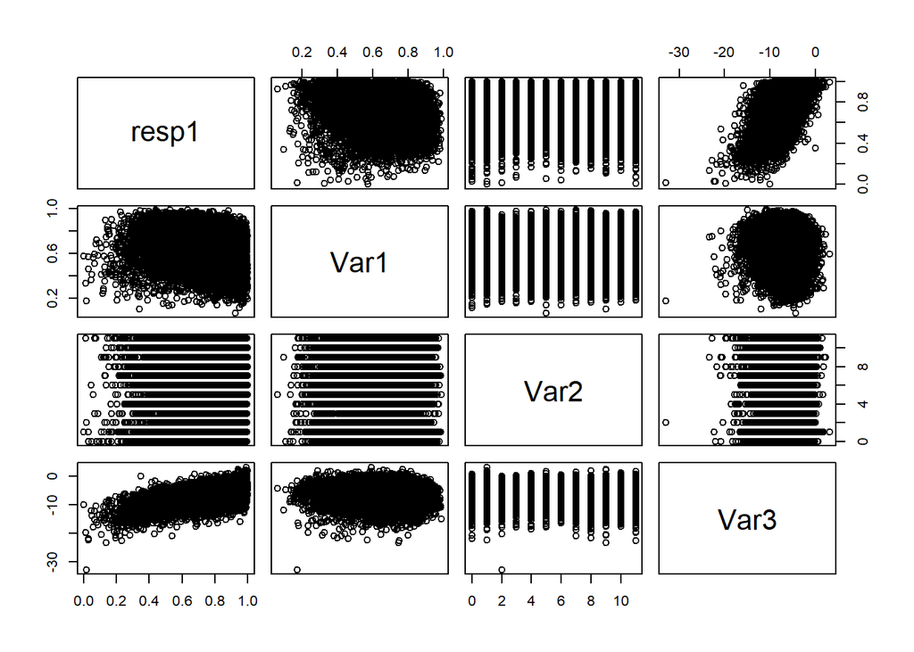

```r
quant <- data_set[,-c(1,2)] #we removed X as it is the ID
pairs(quant[,c(1,2,3,4)])
```

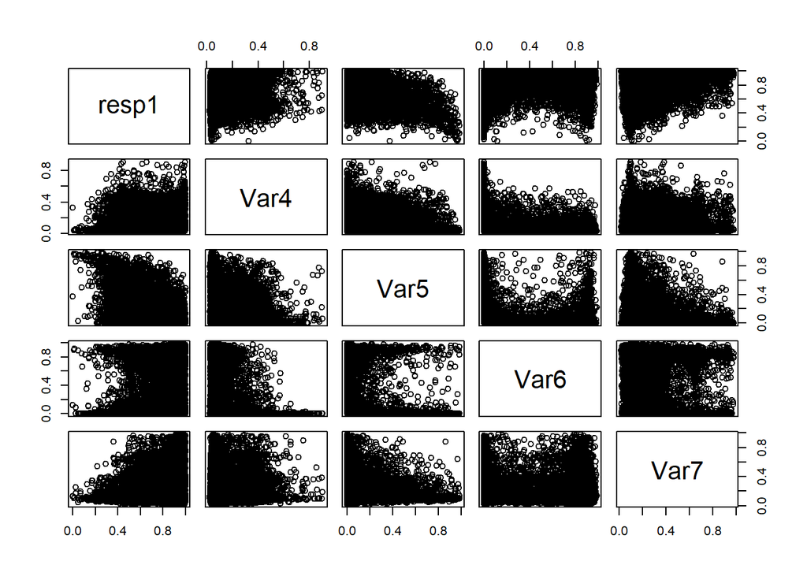

```r
pairs(quant[,c(1,5,6,7,8)])
```

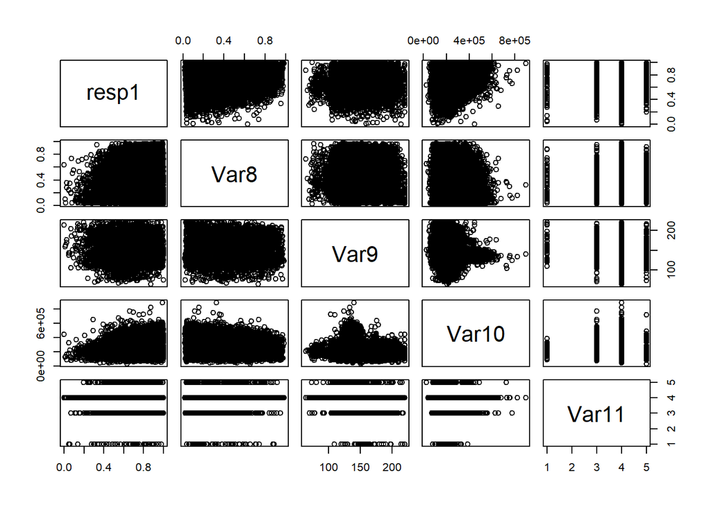

```r
pairs(quant[,c(1,9,10,11,12)])
```

```r
cor(data_set$resp1, quant) #for validation
```

```
##      resp1       Var1       Var2      Var3       Var4       Var5      Var6
## [1,]     1 -0.3251786 0.04626916 0.6065324 -0.1535043 -0.4936375 0.3053776
##           Var7         Var8       Var9     Var10      Var11
## [1,] 0.2277872 -0.009312927 -0.0243437 0.2960197 0.03724584
```

From the correlation shown above, we can deduce that:  
- resp1 has slight to no correlation with variables Var2, Var8, Var9, and Var11. - resp1 has a sufficient positive correlation with variables Var3, Var6, Var7, and Var10. (with itself of course its 100%)  
- resp1 has a sufficient negative correlation with variables Var1, Var4 (not very high), and Var5.

### Task 1 - Exercise - 4

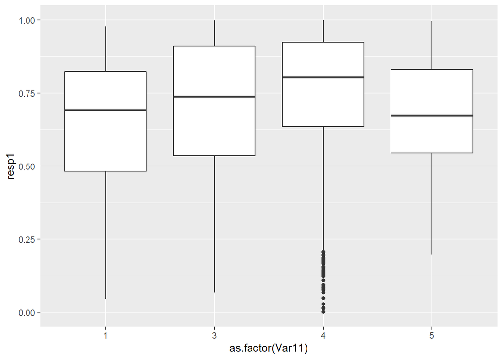

```r
ggplot(data = data_set, mapping = aes(x = as.factor(Var11), y = resp1), color = as.factor(Var11)) + geom_boxplot()
```

### Task 1 - Exercise - 5

```r
set.seed(1234)

tr = data_set %>% slice_sample(prop = 0.7)
te = anti_join(data_set, tr, by = "X")

nrow(tr) / nrow(data_set) #just to ensure that the % is correct
```

```
## [1] 0.6999636
```

```r
nrow(te) / nrow(data_set) # //
```

```
## [1] 0.3000364
```

```r
head(tr)
```

```
##      X resp2 resp1  Var1 Var2    Var3   Var4     Var5     Var6   Var7   Var8
## 1 7452     1 0.268 0.596    6 -16.190 0.1080 0.066100 4.47e-05 0.0792 0.0975
## 2 8016     0 0.680 0.550    6 -10.430 0.0337 0.002340 7.99e-01 0.1100 0.1750
## 3 7162     1 0.948 0.576    0  -5.023 0.2760 0.218000 9.67e-02 0.1000 0.1770
## 4 8086     1 0.695 0.522    2  -7.263 0.0619 0.015200 8.30e-01 0.0923 0.1510
## 5 9196     1 0.736 0.476    2  -5.380 0.0343 0.021700 1.08e-06 0.2030 0.2510
## 6  623     0 0.972 0.621    6  -2.024 0.1070 0.000202 1.82e-03 0.2770 0.3210
##      Var9  Var10 Var11
## 1 149.668 104043     4
## 2 139.974 240010     4
## 3 119.985 204107     4
## 4 135.994 757972     4
## 5 129.084 261853     4
## 6 144.965 249931     4
```

```r
head(te)
```

```
##    X resp2 resp1  Var1 Var2    Var3   Var4     Var5     Var6   Var7  Var8
## 1  2     1 0.493 0.919    1  -8.810 0.0613 0.140000 1.62e-06 0.1220 0.159
## 2  3     0 0.853 0.481    8  -4.104 0.2850 0.017100 4.85e-05 0.2350 0.142
## 3  4     0 0.891 0.801    4  -8.362 0.0544 0.000114 8.35e-01 0.0991 0.063
## 4  7     0 0.539 0.555    1 -12.634 0.6000 0.073800 0.00e+00 0.2240 0.432
## 5  8     1 0.889 0.682    0  -4.166 0.0804 0.005640 0.00e+00 0.3600 0.827
## 6 10     1 0.963 0.771    7  -3.790 0.0672 0.014300 1.70e-01 0.3510 0.518
##      Var9  Var10 Var11
## 1 216.152 126768     4
## 2 154.968 248903     4
## 3 128.008 458710     4
## 4 180.134 143177     4
## 5 138.021 192440     4
## 6 123.992 292767     4
```

```r
lm.fit = lm(resp1~Var11, data = tr) #we are generating a linear model
summary(lm.fit)
```

```
##
## Call:
## lm(formula = resp1 ~ Var11, data = tr)
##
## Residuals:
##      Min       1Q   Median       3Q      Max
## -0.74824 -0.13194  0.04006  0.16006  0.25954
##
## Coefficients:
##             Estimate Std. Error t value Pr(>|t|)
## (Intercept) 0.675011   0.025860  26.103  < 2e-16 ***
## Var11       0.021482   0.006495   3.307 0.000945 ***
## ---
## Signif. codes:  0 '***' 0.001 '**' 0.01 '*' 0.05 '.' 0.1 ' ' 1
##
## Residual standard error: 0.1845 on 11546 degrees of freedom
## Multiple R-squared:  0.0009464,  Adjusted R-squared:  0.0008599
## F-statistic: 10.94 on 1 and 11546 DF,  p-value: 0.0009451
```

```r
pred <- predict(lm.fit, newdata = te)
mse <- mean((pred-te$resp1)^2)
mse #this is the test error
```

```
## [1] 0.03266427
```

### Task 1 - Exercise - 6

```r
data = data_set[,-1] # we are removing X so it wont interfere
mlm.fit = glm(resp1~., data = data)
summary(mlm.fit)
```

```
##
## Call:
## glm(formula = resp1 ~ ., data = data)
##
## Deviance Residuals:
##      Min        1Q    Median        3Q       Max
## -0.67703  -0.06663   0.00737   0.07252   0.50953
##
## Coefficients:
##               Estimate Std. Error t value Pr(>|t|)
## (Intercept)  1.066e+00  1.512e-02  70.492  < 2e-16 ***
## resp21      -2.841e-03  1.755e-03  -1.618  0.10560
## Var1        -2.595e-01  6.331e-03 -40.991  < 2e-16 ***
## Var2         6.884e-04  2.369e-04   2.906  0.00367 **
## Var3         3.405e-02  3.239e-04 105.125  < 2e-16 ***
## Var4         3.485e-02  7.539e-03   4.622 3.83e-06 ***
## Var5        -2.344e-01  5.506e-03 -42.575  < 2e-16 ***
## Var6         1.421e-01  3.093e-03  45.959  < 2e-16 ***
## Var7         8.014e-02  4.963e-03  16.146  < 2e-16 ***
## Var8         1.195e-01  4.081e-03  29.270  < 2e-16 ***
## Var9        -5.195e-04  3.695e-05 -14.060  < 2e-16 ***
## Var10        2.321e-07  1.038e-08  22.360  < 2e-16 ***
## Var11        4.228e-03  3.203e-03   1.320  0.18684
## ---
## Signif. codes:  0 '***' 0.001 '**' 0.01 '*' 0.05 '.' 0.1 ' ' 1
##
## (Dispersion parameter for gaussian family taken to be 0.01167094)
##
##     Null deviance: 555.63  on 16497  degrees of freedom
## Residual deviance: 192.40  on 16485  degrees of freedom
## AIC: -26593
##
## Number of Fisher Scoring iterations: 2
```

- From the summary we can see that some P-values are high and some are low, however the high ones do not mean that they are insignificant but rather that they could have correlations with other variables that are masking their effect. For instance, Var11 was shown before to have a low p-value; however, here it shows a high p-value which indicates that it has a correlation with another variable/s.

```r
loocv <- function(mod){
  hat <- lm.influence(mod)$hat
  mean((residuals(mod)/(1-hat))^2)
}
loocv(mlm.fit)
```

```
## [1] 0.01168221
```

```r
#err = cv.glm(data_set, mlm.fit)$delta[1] #this gives us the test error
#err
#this will take a long time!! So I changed it to the one above.
```

### Task 1 - Exercise - 7

```r
fit <- glm(resp1~Var5+Var6+Var7+Var5:Var6+Var6:Var7+Var5:Var7, data = data)
summary(fit)
```

```
##
## Call:
## glm(formula = resp1 ~ Var5 + Var6 + Var7 + Var5:Var6 + Var6:Var7 +
##     Var5:Var7, data = data)
##
## Deviance Residuals:
##      Min        1Q    Median        3Q       Max
## -0.78445  -0.09979   0.02479   0.11438   0.50449
##
## Coefficients:
##              Estimate Std. Error t value Pr(>|t|)
## (Intercept)  0.729096   0.002943 247.725  < 2e-16 ***
## Var5        -0.426712   0.012613 -33.831  < 2e-16 ***
## Var6         0.121171   0.005420  22.356  < 2e-16 ***
## Var7         0.214167   0.010392  20.608  < 2e-16 ***
## Var5:Var6   -0.169402   0.024414  -6.939 4.11e-12 ***
## Var6:Var7   -0.070775   0.018856  -3.753 0.000175 ***
## Var5:Var7    0.005258   0.055669   0.094 0.924759
## ---
## Signif. codes:  0 '***' 0.001 '**' 0.01 '*' 0.05 '.' 0.1 ' ' 1
##
## (Dispersion parameter for gaussian family taken to be 0.02316784)
##
##     Null deviance: 555.63  on 16497  degrees of freedom
## Residual deviance: 382.06  on 16491  degrees of freedom
## AIC: -15287
##
## Number of Fisher Scoring iterations: 2
```

From the above summary, we can deduce that:  
- Var5 and Var6 do have an interaction as their p-value is low  
- Var6 and Var7 do as well have an interaction  
- Var5 and Var7 do NOT have an interaction as their p-value is very high.

```r
cv.glm(data, fit, K=10)$delta[1] #this is for the test error using 10 folds
```

```
## [1] 0.02318773
```

### Task 1 - Exercise - 8

```r
set.seed(1234)

tr = data_set %>% slice_sample(prop = 0.8)
te = anti_join(data_set, tr, by = "X")

nrow(tr) / nrow(data_set) #just to ensure that the % is correct
```

```
## [1] 0.7999758
```

```r
nrow(te) / nrow(data_set) # //
```

```
## [1] 0.2000242
```

```r
head(tr)
```

```
##      X resp2 resp1  Var1 Var2    Var3   Var4     Var5     Var6   Var7   Var8
## 1 7452     1 0.268 0.596    6 -16.190 0.1080 0.066100 4.47e-05 0.0792 0.0975
## 2 8016     0 0.680 0.550    6 -10.430 0.0337 0.002340 7.99e-01 0.1100 0.1750
## 3 7162     1 0.948 0.576    0  -5.023 0.2760 0.218000 9.67e-02 0.1000 0.1770
## 4 8086     1 0.695 0.522    2  -7.263 0.0619 0.015200 8.30e-01 0.0923 0.1510
## 5 9196     1 0.736 0.476    2  -5.380 0.0343 0.021700 1.08e-06 0.2030 0.2510
## 6  623     0 0.972 0.621    6  -2.024 0.1070 0.000202 1.82e-03 0.2770 0.3210
##      Var9  Var10 Var11
## 1 149.668 104043     4
## 2 139.974 240010     4
## 3 119.985 204107     4
## 4 135.994 757972     4
## 5 129.084 261853     4
## 6 144.965 249931     4
```

```r
head(te)
```

```
##    X resp2 resp1  Var1 Var2    Var3   Var4     Var5     Var6  Var7  Var8
## 1  3     0 0.853 0.481    8  -4.104 0.2850 1.71e-02 4.85e-05 0.235 0.142
## 2  7     0 0.539 0.555    1 -12.634 0.6000 7.38e-02 0.00e+00 0.224 0.432
## 3  8     1 0.889 0.682    0  -4.166 0.0804 5.64e-03 0.00e+00 0.360 0.827
## 4 10     1 0.963 0.771    7  -3.790 0.0672 1.43e-02 1.70e-01 0.351 0.518
## 5 11     1 0.888 0.605    6  -6.142 0.0428 1.03e-04 7.99e-01 0.340 0.546
## 6 19     1 0.900 0.487    0  -4.417 0.0482 6.79e-05 0.00e+00 0.358 0.484
##      Var9  Var10 Var11
## 1 154.968 248903     4
## 2 180.134 143177     4
## 3 138.021 192440     4
## 4 123.992 292767     4
## 5 139.989 520858     4
## 6 149.937 204000     4
```

```r
degree = 2:4
mse = 2:4

for (d in degree){
    resp1_poly <- lm(resp1 ~ poly(Var2,d,raw=TRUE), data = tr)

    pred <- predict(resp1_poly, te)

    mse[d-1] <- mean((te$resp1 - pred)^2)
    #if (d==degree){
      #print minimum MSE to highest MSE, done by a small loop
    #}
}

mse
```

```
## [1] 0.03352505 0.03349526 0.03347068
```

```r
degree
```

```
## [1] 2 3 4
```

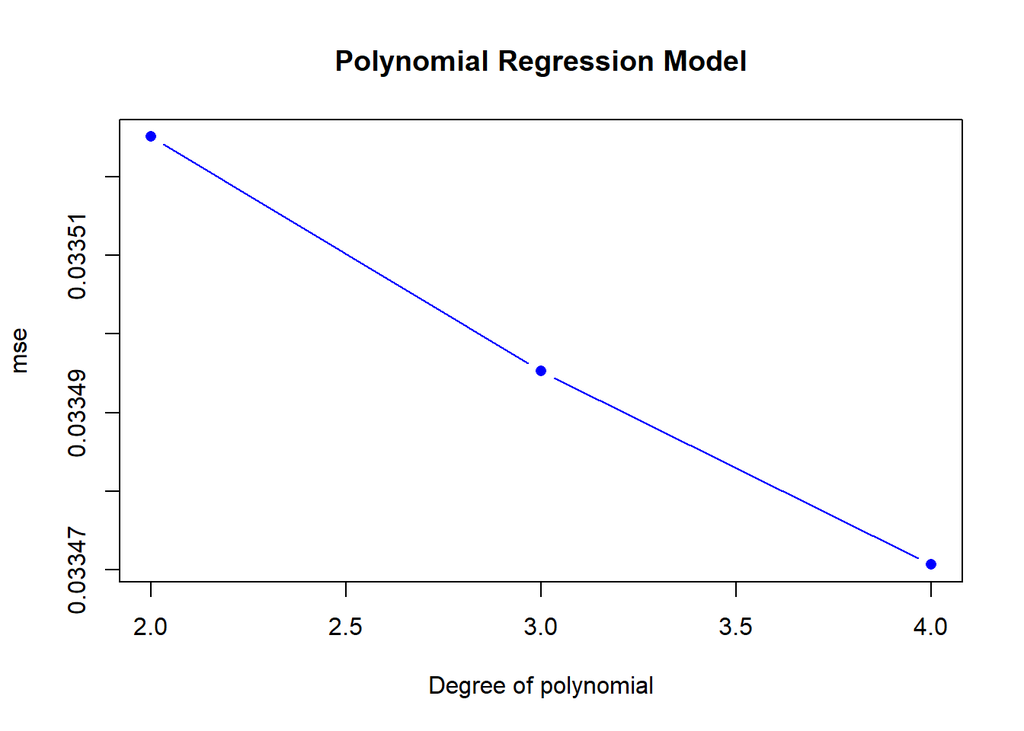

```r
plot(degree, mse, type = "b", col = "blue", pch = 16, main = "Polynomial Regression Model", xlab = "Degree of polynomial")
```

From the shown data, we can see that the quartic model has a slightly lower MSE than the cubic, and the cubic model has a slightly lower MSE than the quadratic model. (visibil in the graph)

## Task 2

### Task 2 - Exercise - 1

```r
set.seed(1234)
#View(data_set)
temp = data_set$resp2
temp = ifelse(temp=="0", "No", "Yes") #since it is a factor as we changed it to be, we can change 0 and 1 to No and Yes respectively
data_set$resp2 = temp
#View(data_set)

fit2 <- glm(resp2~Var2+Var10, data = data, family = binomial)
cv.glm(data, fit2, K=5)$delta[1] #this is for the test error using 10 folds
```

```
## [1] 0.2318292
```

### Task 2 - Exercise - 2

```r
set.seed(1234)

tr = data_set %>% slice_sample(prop = 0.7)
te = anti_join(data_set, tr, by = "X")

nrow(tr) / nrow(data_set) #just to ensure that the % is correct
```

```
## [1] 0.6999636
```

```r
nrow(te) / nrow(data_set) # //
```

```
## [1] 0.3000364
```

```r
head(tr)
```

```
##      X resp2 resp1  Var1 Var2    Var3   Var4     Var5     Var6   Var7   Var8
## 1 7452   Yes 0.268 0.596    6 -16.190 0.1080 0.066100 4.47e-05 0.0792 0.0975
## 2 8016    No 0.680 0.550    6 -10.430 0.0337 0.002340 7.99e-01 0.1100 0.1750
## 3 7162   Yes 0.948 0.576    0  -5.023 0.2760 0.218000 9.67e-02 0.1000 0.1770
## 4 8086   Yes 0.695 0.522    2  -7.263 0.0619 0.015200 8.30e-01 0.0923 0.1510
## 5 9196   Yes 0.736 0.476    2  -5.380 0.0343 0.021700 1.08e-06 0.2030 0.2510
## 6  623    No 0.972 0.621    6  -2.024 0.1070 0.000202 1.82e-03 0.2770 0.3210
##      Var9  Var10 Var11
## 1 149.668 104043     4
## 2 139.974 240010     4
## 3 119.985 204107     4
## 4 135.994 757972     4
## 5 129.084 261853     4
## 6 144.965 249931     4
```

```r
head(te)
```

```
##    X resp2 resp1  Var1 Var2    Var3   Var4     Var5     Var6   Var7  Var8
## 1  2   Yes 0.493 0.919    1  -8.810 0.0613 0.140000 1.62e-06 0.1220 0.159
## 2  3    No 0.853 0.481    8  -4.104 0.2850 0.017100 4.85e-05 0.2350 0.142
## 3  4    No 0.891 0.801    4  -8.362 0.0544 0.000114 8.35e-01 0.0991 0.063
## 4  7    No 0.539 0.555    1 -12.634 0.6000 0.073800 0.00e+00 0.2240 0.432
## 5  8   Yes 0.889 0.682    0  -4.166 0.0804 0.005640 0.00e+00 0.3600 0.827
## 6 10   Yes 0.963 0.771    7  -3.790 0.0672 0.014300 1.70e-01 0.3510 0.518
##      Var9  Var10 Var11
## 1 216.152 126768     4
## 2 154.968 248903     4
## 3 128.008 458710     4
## 4 180.134 143177     4
## 5 138.021 192440     4
## 6 123.992 292767     4
```

```r
tr = tr %>% dplyr::select(-X)
te = te %>% dplyr::select(-X)

lda.mod <- lda(resp2 ~ Var2+Var10, data = tr)

#summary(lda.mod)
lda.mod
```

```
## Call:
## lda(resp2 ~ Var2 + Var10, data = tr)
##
## Prior probabilities of groups:
##        No       Yes
## 0.4486491 0.5513509
##
## Group means:
##         Var2    Var10
## No  6.397800 253592.0
## Yes 4.539186 246792.1
##
## Coefficients of linear discriminants:
##                 LD1
## Var2  -2.783677e-01
## Var10 -6.934973e-07
```

```r
lda.mod.pred <- predict(newdata = te, lda.mod)

#nrow(as.data.frame(lda.mod.pred))
#head(lda.mod.pred$x)
#names(lda.mod.pred)
```

```r
conf <- table(predicted = lda.mod.pred$class, reference = te$resp2)

f <- function(conftable) {
  se <- conftable[2,2]/(conftable[1,2] + conftable[2,2]) #for the true positive =>  #sensitivity
  sp <- conftable[1,1]/(conftable[1,1] + conftable[2,1]) #for the true negative = > #specificity
  acc <- sum(diag(conftable)) / sum(conftable) #for the accuracy
  return(c(sensitivity = se, specificity = sp, accuracy = acc))
}

f(conf) #this will display the sensitivity, specificity & accuracy on the screen
```

```
## sensitivity specificity    accuracy
##   0.6402039   0.4600726   0.5600000
```

The chunk of code above generates the sensitivity, specificity & accuracy of the LDA model  
- The sensitivity shows the true positive  
- The specificity shows the true negative  
- The accuracy shows how many True positive and negative do we have from the total

### Task 2 - Exercise - 3

```r
qda.mod <- qda(resp2 ~ Var2+Var10, data = tr)

#summary(qda.mod)
#qda.mod

qda.mod.pred <- predict(qda.mod, newdata = te)

f(table(qda.mod.pred$class, te$resp2))
```

```
## sensitivity specificity    accuracy
##   0.6540422   0.4718693   0.5729293
```

The chunk of code above generates the sensitivity, specificity & accuracy of the QDA model  
- The sensitivity here is slightly higher than the LDA model - The specificity here is also slightly higher than the LDA model - The accuracy here is as well higher than the LDA model

### Task 2 - Exercise - 4

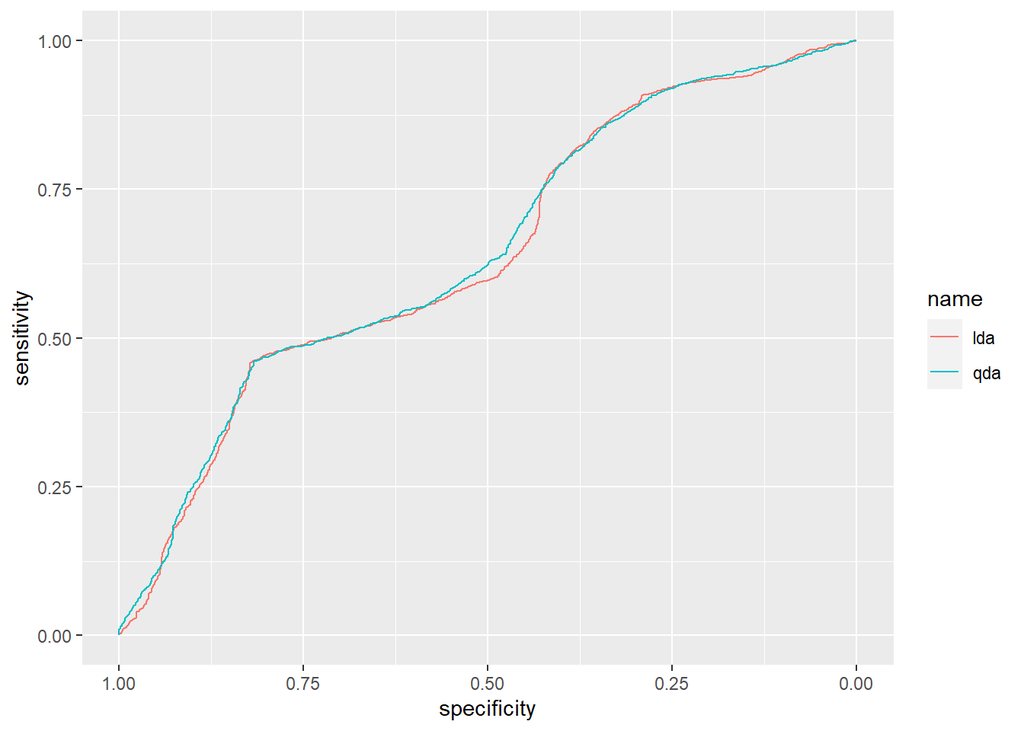

```r
#usinf library pROC

#names(lda.mod.pred)

roc.lda <- roc(response = te$resp2, predictor = lda.mod.pred$posterior[,2])
roc.qda <- roc(response = te$resp2, predictor = qda.mod.pred$posterior[,2])
ggroc(list(lda=roc.lda,
           qda=roc.qda))
```

```r
auc(roc.lda)
```

```
## Area under the curve: 0.6426
```

```r
auc(roc.qda)
```

```
## Area under the curve: 0.6479
```

A suitable way to compare the models is using the pROC library.  
As we can see from the graph generated, both models are extremely similar; However, the qda model seems to be very slightly better than the lda model in this case. We can even see that the area under the curve for the QDA model is slightly higher as well than the LDA model.